# Indoor Coverage with the PyLayers Multi Wall model

> A Multi wall model accounts only for the attenuation along the direct path between Tx and Rx.

> This kind of approach do not provide any information about delay spread or multi paths but it can nevertheless be useful in different context when the point is optimization of an indoor radio network. The main advantage of the MultiWall approach is that is provides a fast indication about the propagation losses.

> A ray tracing approach is much more precise, but also is much more time consuming and depending on the purpose, it could be relevant to proceed with a simpler and faster site-specific approach as the Multiwall model.

> **`PyLayers`** provides a multiwall module which heavily relies on the core class **`Slab`**. Notice that, the same core **`Slab`** module is used for Ray tracing and MultiWall model approaches.

Let see, how it works. First let's import the `coverage` module. And the `time` module for performance evaluation.

```python
from pylayers.antprop.coverage import *
import time
```

```
WARNING:traits.has_traits:DEPRECATED: traits.has_traits.wrapped_class, 'the 'implements' class advisor has been deprecated. Use the 'provides' class decorator.
```

Instantiate a coverage object. By defaut the `TA-Office.ini` layout is loaded.

The coverage information is placed in the **coverage.ini** file in the project directory.

Below is an example such a configuration file.

```python
!cat $BASENAME/ini/coverage.ini
```

```
[grid]
nx = 20
ny = 10
boundary = [20,0,30,20]
full = True

[layout]
filename = TA-Office.ini ; 0 40 0 15
;filename = W2PTIN.ini
;filename = Lstruc.str

[ap]
0 = {'name':'room1','wstd':'ieee80211b','p':(1,12,1.2),'PtdBm':0,'chan':[11]}
1 = {'name':'room2','wstd':'ieee80211b','p':(10,2,1.2),'PtdBm':0,'chan':[11]}
2 = {'name':'room3','wstd':'ieee80211b','p':(20,1,1.2),'PtdBm':0,'chan':[11]}
3 = {'name':'room4','wstd':'ieee80211b','p':(36.5,1.5,1.2),'PtdBm':0,'chan':[11]}
4 = {'name':'room5','wstd':'ieee80211b','p':(25,12,1.2),'PtdBm':0,'chan':[11]}
[rx]
sensitivity  = -80
bandwidthmhz = 3
temperaturek = 300
noisefactordb = 13

[show]
show = True
```

The ini file contains 5 sections.

- [grid] section

  This section precise the size of the grid. By default the grid is placed over the whole region of the Layout. A selected region can also be defined whith the `boundary` list
- [layout] section

  The name of the layout file
- [ap] section

  A dictionnary of access point precising the standard, the used channel, the emitted power and the position of the access point.
- [show] section

```python
# Create a Coverage object from coverag.ini file
C = Coverage('coverage.ini')
```

`C` has a dictionnary `dap` which gathered various information about each access points of the simulation.

```python
C.dap[0]
```

```
name : room1
p : (1, 12, 1.2)
PtdBm : 0
chanels  : [11]   2.462 : [2.451,2.473]
sensdBm : -94
nant : 1
```

```python
C.fGHz
```

```
array([ 2.412,  2.417,  2.422,  2.427,  2.432,  2.437,  2.442,  2.447,
        2.452,  2.457,  2.462,  2.467,  2.472])
```

The coverage object has a `__repr__` method which summarizes different parameters of the current coverage object

```python
C
```

```
Layout file : TA-Office.ini

-----list of Access Points ------
name : room1
p : (1, 12, 1.2)
PtdBm : 0
chanels  : [11]   2.462 : [2.451,2.473]
sensdBm : -94
nant : 1

name : room2
p : (10, 2, 1.2)
PtdBm : 0
chanels  : [11]   2.462 : [2.451,2.473]
sensdBm : -94
nant : 1

name : room3
p : (20, 1, 1.2)
PtdBm : 0
chanels  : [11]   2.462 : [2.451,2.473]
sensdBm : -94
nant : 1

name : room4
p : (36.5, 1.5, 1.2)
PtdBm : 0
chanels  : [11]   2.462 : [2.451,2.473]
sensdBm : -94
nant : 1

name : room5
p : (25, 12, 1.2)
PtdBm : 0
chanels  : [11]   2.462 : [2.451,2.473]
sensdBm : -94
nant : 1

-----Rx------
rxsens (dBm) : -80
bandwith (Mhz) : [20 20 20 20 20]
temperature (K) : 300
noisefactor (dB) : 13

--- Grid ----
nx : 20
ny : 10
nlink : 1000
full grid : True
boundary (xmin,ymin,xmax,ymax) : [20, 0, 30, 20]
```

Then, the coverage calculation is launched by calling the `cover()` method

```python
tic = time.time()
C.cover()
toc = time.time()
print "Execution time : %2.3f " % (toc-tic)
```

```
Execution time : 0.714
```

Let display the current Layout with hidding nodes.

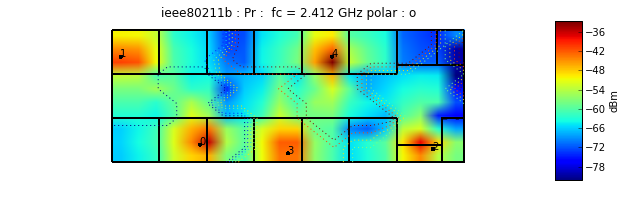

```python
from matplotlib.pyplot import *
%matplotlib inline
fig=figure(figsize=(10,5))
C.L.display['nodes']=False
C.L.display['ednodes']=False
f,a = C.show(fig=fig)
```

The shadowing map coverage results can be displayed by invoquing various functions.

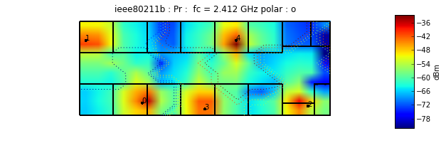

```python
fig=figure(figsize=(10,5))
f,a=C.show(fig=fig,typ='pr')
```

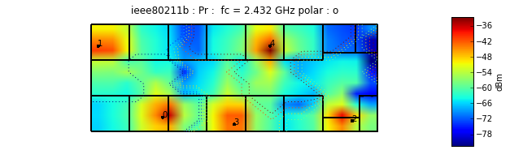

```python
fig=figure(figsize=(10,5))
f,a=C.show(fig=fig,typ='pr',f=4)
```

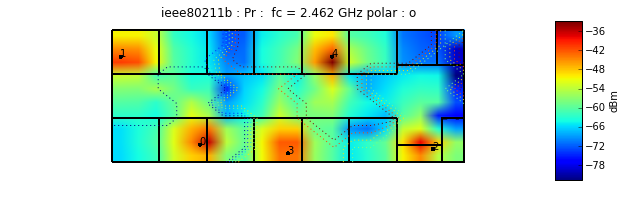

```python
fig=figure(figsize=(10,5))
f,a=C.show(fig=fig,typ='pr',f=10)
```

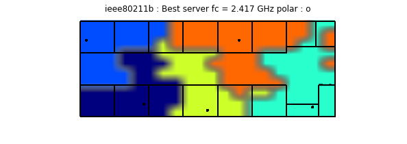

```python
fig=figure(figsize=(10,5))
f,a=C.show(fig=fig,typ='best',f=1)
```

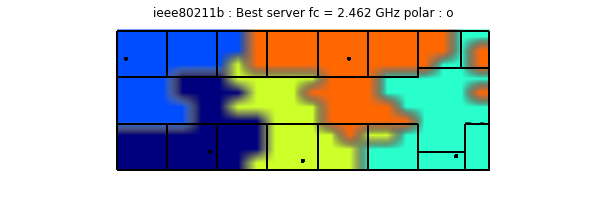

```python
fig=figure(figsize=(10,5))
f,a=C.show(fig=fig,typ='best',f=10)
```

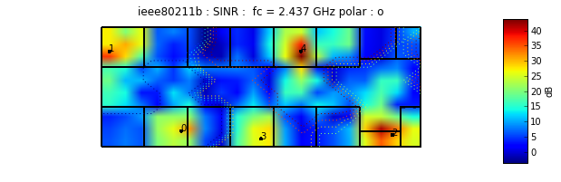

```python
fig=figure(figsize=(10,5))
C.show(fig=fig,f=5,typ='sinr')
```

As you have noticed the calculation has been done for all the center frequencies of the selected standard. This is done in prevision of further channel optimizations.

```python
C2 = Coverage('coverage2.ini')
C2.cover()
```

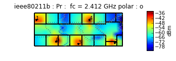

```python
C2.show(ftyp='pr')
```

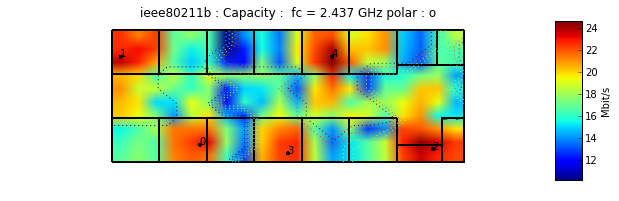

```python
fig=figure(figsize=(10,5))
C.show(fig=fig,f=5,typ='capacity',dB=False)
```

All simulated quantities are stored in linear scale.

```python
C2.Lw[0,0,0]
```

```
0.27294476543198881
```

```python
C2.freespace[0,0,0]
```

```
9.4414212324159392e-07
```